# Data Transformations

Author

Danielius Rimas, Kassandra Vroulli, Isabella Braune

Published

October 20, 2026

# Project Aim

Het Epos is a primary school which opened in Rotterdam Zuid in 2020. Het Epos aims to demonstrate that differences in learning outcomes are related to pupils’ backgrounds, but importantly also to the quality of education. Within primary education, the school focuses on high-quality teaching, pupil support and parental engagement. The aim of this project is to examine which aspects of early education the school should prioritise to maximise pupils’ development during the kindergarten years and their success throughout the rest of their school career.Specifically, two sub-questions which could be explored are:

**1.What effects does spending a longer period in kindergarten have on pupils’** **cognitive, social-emotional and executive development, and on their** **functioning in Years 3 and 4?**

In order to examine this question the data will need to contain information pertaining to (a) the amount of years/months children spent in kindergarten, (b) enough variation in terms of how long they spent in kindergarten, to enable a comparison between children who stayed longer, (c) variables that provide information about their cognitive, social-emotional and executive development and lastly (d) information about these pupils that are now in grade 3 or above.

**2.What effects does a teaching focus on learning objectives aligned with** **Years 3 and 4 have on pupils’ academic achievement and subsequent educational** **pathways?** Will need to be examined in a similar manner.

# Data Preprocessing

Running the code below and loading the data should work if you went through the steps as described in README.md. The data should be stored in the specified folder included in .gitignore, so will not be uploaded online and stay in your local environment.

## 1. Pupils

The pupil data is such that each variable is of the correct type and column names do not contain any spaces. - imported such that the dates are of type date. These are now in the format YYYY-mm-dd. The column names have been changed to contain no spaces. old_name = “new_name”

- Pupil ID = “ID”
- Date of birth = “birth_date”
- Current class = “curr_class”
- Current year group = “curr_year_group”
- Pupil = “pupil”
- Start date = “start_date”

```
# A tibble: 163 × 6
   ID        birth_date curr_class    curr_year_group pupil           start_date
   <chr>     <date>     <chr>                   <dbl> <chr>           <date>
 1 Pupil 191 2022-06-02 Starter group               0 Noor Verbeek    2026-06-02
 2 Pupil 192 2022-07-06 Starter group               0 Daan Veldman    2026-07-06
 3 Pupil 193 2022-08-11 Starter group               0 Isa Van Loon    2026-08-31
 4 Pupil 194 2022-06-14 Starter group               0 Floris De Ruit… 2026-06-17
 5 Pupil 195 2022-08-11 Starter group               0 Lena Smeets     2026-08-31
 6 Pupil 196 2022-08-13 Starter group               0 Niels Van Essen 2026-08-31
 7 Pupil 197 2022-06-02 Starter group               0 Femke Bosman    2026-06-02
 8 Pupil 198 2022-05-30 Starter group               0 Cas De Vos      2026-06-01
 9 Pupil 199 2022-07-24 Starter group               0 Sofie Ter Horst 2026-08-31
10 Pupil 200 2022-08-07 Starter group               0 Teun Van Dalen  2026-08-31
# ℹ 153 more rows
```

#### Pupil Selection

Firstly, the pupile data provides information about the current group of the pupils. As we need information about how these pupils performed in group 3-4, pupils currently in the startergroup, group 1, and group 2, cannot be included in our analysis. Therefore, pupils currently in group 0, 1, and 2 will be filtered out. After removing these pupils the data set contains 104 entries. The names of these 104 pupils are stored in a vector which will be employed to extract their data from other files.

```
# A tibble: 104 × 6
   ID        birth_date curr_class curr_year_group pupil              start_date
   <chr>     <date>     <chr>                <dbl> <chr>              <date>
 1 Pupil 002 2019-08-01 Group 3                  3 Olivier Van der M… 2023-08-21
 2 Pupil 013 2020-07-18 Group 3                  3 Maud Van der Lind… 2024-08-26
 3 Pupil 022 2020-09-26 Group 3                  3 Jesse Vermeulen    2024-09-27
 4 Pupil 042 2020-01-11 Group 3                  3 Jens Dijkstra      2024-01-11
 5 Pupil 043 2020-08-09 Group 3                  3 Elin Arslan        2024-08-26
 6 Pupil 053 2020-07-26 Group 3                  3 Sophie Peters      2024-08-26
 7 Pupil 058 2020-05-12 Group 3                  3 Evi Kok            2024-05-13
 8 Pupil 062 2020-07-27 Group 3                  3 Max Smits          2024-08-26
 9 Pupil 064 2020-07-19 Group 3                  3 Yara El Idrissi    2024-08-26
10 Pupil 076 2020-06-05 Group 3                  3 Evi Van Wijk       2024-06-05
# ℹ 94 more rows
```

## 2. Observations group 1 and 2

This data file contains observations from students in group 1 and 2. Firstly, the data is imported in the correct format. Secondly, only the rows containing information of the selected pupils above is retained. After filtering the data, this file contains 96821 rows.

#### Observation Selection

Select only the observations of pupils in our selected sample.

```
# A tibble: 96,821 × 11
   Vak     Domein Leerpad Leerpadcode Leerling Score Datum      Periode Jaargang
   <chr>   <chr>  <chr>   <chr>       <chr>    <dbl> <date>       <dbl> <chr>
 1 Kleine… VKS    NA      KM5.1_E1    Ruben A…     2 2020-05-27       1 2019/20…
 2 Kleine… VKS    NA      KM5.1_E1    Anna Pe…     0 2020-05-27       1 2019/20…
 3 Kleine… OV     NA      KM10.1_E1   Ruben A…     3 2020-05-27       1 2019/20…
 4 Kleine… OV     NA      KM10.1_E1   Anna Pe…     2 2020-05-27       1 2019/20…
 5 Rekenen TG     NA      NA          Anna Pe…     3 2020-05-27       1 2019/20…
 6 Rekenen TG     NA      NA          Ruben A…     1 2020-05-27       1 2019/20…
 7 Rekenen TG     NA      TG4.1_S1    Ruben A…     1 2020-05-27       1 2019/20…
 8 Rekenen TG     NA      TG4.1_S1    Anna Pe…     3 2020-05-27       1 2019/20…
 9 Rekenen MT     NA      NA          Ruben A…     2 2020-05-27       1 2019/20…
10 Rekenen MT     NA      NA          Anna Pe…     2 2020-05-27       1 2019/20…
# ℹ 96,811 more rows
# ℹ 2 more variables: Vaktype <chr>, Groep <chr>
```

## 3. Time spent in Kindergarten

In order to examine how long each pupil stayed in kindergarten, and whether these periods differ enough between pupils to compare between groups, we will need to determine how long each pupil spent in kindergarten.

This could be estimated from the start date of each pupil and the last observation which was made for them in group 1/2. This will not provide a precise estimate but will give us a rough estimation of whether we can proceed.

```
# A tibble: 104 × 11
   ID        birth_date curr_class curr_year_group pupil   start_date first_obs
   <chr>     <date>     <chr>                <dbl> <chr>   <date>     <date>
 1 Pupil 002 2019-08-01 Group 3                  3 Olivie… 2023-08-21 2024-09-03
 2 Pupil 013 2020-07-18 Group 3                  3 Maud V… 2024-08-26 2024-09-13
 3 Pupil 022 2020-09-26 Group 3                  3 Jesse … 2024-09-27 2024-10-10
 4 Pupil 042 2020-01-11 Group 3                  3 Jens D… 2024-01-11 2024-01-26
 5 Pupil 043 2020-08-09 Group 3                  3 Elin A… 2024-08-26 2024-09-09
 6 Pupil 053 2020-07-26 Group 3                  3 Sophie… 2024-08-26 2024-09-03
 7 Pupil 058 2020-05-12 Group 3                  3 Evi Kok 2024-05-13 2024-09-13
 8 Pupil 062 2020-07-27 Group 3                  3 Max Sm… 2024-08-26 2024-09-13
 9 Pupil 064 2020-07-19 Group 3                  3 Yara E… 2024-08-26 2024-09-03
10 Pupil 076 2020-06-05 Group 3                  3 Evi Va… 2024-06-05 2024-09-13
# ℹ 94 more rows
# ℹ 4 more variables: last_obs <date>, n_obs <int>, kindergarten_days <dbl>,
#   kindergarten_years <dbl>
```

#### Robustness Checks

Eyebaling the days spent in kindergarten above indicate there are differences in time spent in kindergarten. However, a few assumptions have been made which need to be verified to ensure this is truly representative of their time spent in kindergarten.

Firstly, the variable start_date has now been interperted as the date at which pupils start school. The following checks will therefore be performed, by computing the number of days between the childs 4th birthday and the start date at school. (a) whether the start_date is after the child’s 4th birthday (flag potential mistakes in the data), (b) the child started school no more than 60 days after their birthday (as this school only accepts children that just turned 4), (c) there are no observations before the start date.

Secondly, the time spent in kindergarten has now been estimated from the date at which the last observation was made in grade 1/2 of each pupil. However, if these dates differ significanlty or were registered a long time before the summer holiday (July/ August) we cannot infer how long these children spent in kindergarten. Therefore, the second checks verifies whether the last observation was in july or august (and is not missing).

Thirdly, as a robustness check we can verify whether the pupils current grade year corresponds to the year which they left kindergarten. First by looking at which year the pupil left kindergarten. As school year run from September to August, if the last observation was made between January and August the pupil left kindergarten that year, otherwise the year after. If this calculation is correct, then the expected_end_year should be equal to the end year. Sp for pupils now in grade 4, the end of kindergarten should have been in 2025, and pupils in group 3 2026. e.g. reference year = 2026, current group year = 4 -3 = 1, so ended kindergarten in 2025.

To analyse which pupils fail these checks and why, a table is shown below with which pupils failed which check together with the information which could explain why these checks failed.

```
# A tibble: 1 × 5
  n_pupils check_start check_last_obs check_group all_checks_ok
     <int>       <int>          <int>       <int>         <int>
1      104         103             85          96            79
```

```
# A tibble: 25 × 12
   pupil             curr_year_group birth_date start_date first_obs  last_obs
   <chr>                       <dbl> <date>     <date>     <date>     <date>
 1 Lucas Arslan                    3 2019-08-01 2023-08-21 2023-09-22 2025-07-02
 2 Elif Rahmani                    4 2018-10-26 2022-10-31 2022-11-01 2024-06-25
 3 Roos Aksoy                      4 2018-03-06 2022-03-09 NA         NA
 4 Lars Bakker                     4 2018-09-19 2022-09-19 2022-09-28 2024-06-19
 5 Zeynep De Graaf                 4 2018-08-22 2022-08-22 2022-08-29 2024-06-25
 6 Julia Postma                    5 2018-09-05 2022-09-05 2022-08-29 2024-06-25
 7 Stijn Van der Li…               5 2018-12-12 2022-12-12 NA         NA
 8 Eva Aksoy                       7 2016-07-02 2020-07-02 2020-07-16 2021-12-23
 9 Maud Kok                        7 2016-07-07 2020-07-07 2020-10-02 2021-12-23
10 Sanne Ait Ali                   7 2016-09-26 2020-09-28 2020-10-02 2021-12-23
# ℹ 15 more rows
# ℹ 6 more variables: days_after_4th_bday <dbl>, end_year <dbl>,
#   expected_end_year <dbl>, check_start <lgl>, check_last_obs <lgl>,
#   check_group <lgl>
```

#### Distribution of time spent in kindergarten

```
# A tibble: 1 × 6
      n  mean    sd   min median   max
  <int> <dbl> <dbl> <dbl>  <dbl> <dbl>
1    79  2.02 0.318  1.29   2.04  2.84
```

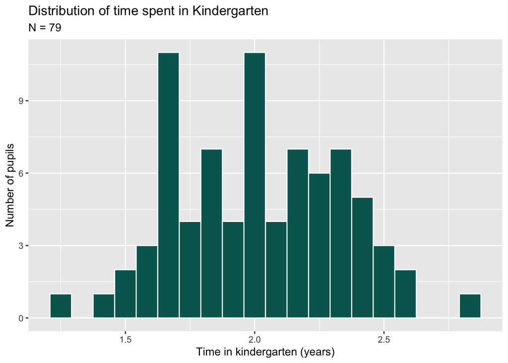

# RQ1 - Kindergarten duration and functioning in Years 3 & 4

## Time spent in Kindergarten and need for extra support

As outlined above, pupils currently in grade 3 till 6, of whom we have observations made in group 1 and 2, and passed all robustness were included in the final sample, resulting in a total sample of 79 students (N).

To determine which developmental outcomes are associated with time spent in kindergarten we will examine the requested support interventions for the selected pupil sample. The data containing information about the support interventions does not contain information about which grade pupils were in when the requests were made. Therefore, the following steps will be taken before analysis this outcome measure.  
(1) calculating the grade pupils were in when the request was made (2) filtering out the data of our selected sample

#### selected sample support intervention

```
# A tibble: 27 × 2
# Groups:   student_name [27]
   student_name          n
   <chr>             <int>
 1 Aya Van der Wal       3
 2 Elin De Bruin         7
 3 Eva Jacobs            3
 4 Eva Kok               1
 5 Evi De Bruin          3
 6 Evi Kaya              1
 7 Joris Van Leeuwen     3
 8 Lars Van Wijk         1
 9 Levi Kuipers          4
10 Leyla Jansen          2
# ℹ 17 more rows
```

```
# A tibble: 27 × 9
   pupil          birth_date curr_class curr_year_group start_date n_obs
   <chr>          <date>     <chr>                <dbl> <date>     <int>
 1 Roos Benali    2019-06-21 Group 4                  4 2023-06-21   923
 2 Sanne Prins    2019-05-18 Group 4                  4 2023-05-19   883
 3 Youssef Prins  2019-08-12 Group 4                  4 2023-08-21   823
 4 Lieke Kuipers  2019-04-16 Group 4                  4 2023-04-19   976
 5 Lars Van Wijk  2019-04-02 Group 4                  4 2023-04-04   664
 6 Eva Kok        2019-03-14 Group 4                  4 2023-03-15  1164
 7 Leyla Jansen   2019-11-03 Group 4                  4 2023-11-06   542
 8 Liv El Idrissi 2018-07-16 Group 5/6                5 2022-08-22   889
 9 Roos Jansen    2018-12-23 Group 5/6                5 2023-01-09   751
10 Eva Jacobs     2018-08-16 Group 5/6                5 2022-08-22   966
# ℹ 17 more rows
# ℹ 3 more variables: kindergarten_days <dbl>, kindergarten_years <dbl>,
#   rounded_kg_years <dbl>
```

```
# A tibble: 107 × 17
   school_yr  term year_term record student_id  student_name referral_date need
       <dbl> <dbl> <chr>      <dbl> <chr>       <chr>        <date>        <chr>
 1      2324     1 2324.1        21 Leerling 0… Aya Van der… 2022-10-31    Moto…
 2      2324     1 2324.1        26 Leerling 1… Lieke Van D… 2023-06-01    Moto…
 3      2324     2 2324.2        21 Leerling 0… Aya Van der… 2022-10-31    Moto…
 4      2324     2 2324.2        26 Leerling 1… Lieke Van D… 2023-06-01    Moto…
 5      2324     2 2324.2        66 Leerling 1… Nova Smit    2024-02-12    Soci…
 6      2324     3 2324.3        26 Leerling 1… Lieke Van D… 2023-06-01    Moto…
 7      2324     3 2324.3        63 Leerling 0… Milan Postma 2024-03-18    Moto…
 8      2324     3 2324.3        66 Leerling 1… Nova Smit    2024-02-12    Soci…
 9      2324     3 2324.3        67 Leerling 0… Sanne Van V… 2024-03-08    Lang…
10      2324     3 2324.3        80 Leerling 1… Nova Smit    2024-03-18    Lear…
# ℹ 97 more rows
# ℹ 9 more variables: focus <chr>, started <chr>, start_date <date>,
#   weeks_est <dbl>, support_type <chr>, next_step <chr>,
#   curr_year_group <dbl>, start_year <dbl>, group_at_time <dbl>
```

The table above shows that only the support data of 27 pupils is available to us. This can be explained by the year in which this data was recorded, as it does not include the support requests which were made this school year. Children currently in grade 3 therefore have no support intervention data, thereby limiting our analysis. We will however briefly explore whether certain differences can be observed for these 27 pupils, in terms of their time spent in kindergarten.

#### Number of support requests in each grade

```
# A tibble: 26 × 12
   pupil                 birth_date curr_class curr_year_group start_date n_obs
   <chr>                 <date>     <chr>                <dbl> <date>     <int>
 1 Luuk Vermeulen        2019-06-01 Group 4                  4 2023-06-01   800
 2 Aya Van der Ven       2018-12-18 Group 4                  4 2022-12-19  1098
 3 Julia Van der Heijden 2019-07-06 Group 4                  4 2023-07-06   615
 4 Roos Benali           2019-06-21 Group 4                  4 2023-06-21   923
 5 Sanne Prins           2019-05-18 Group 4                  4 2023-05-19   883
 6 Elif De Groot         2019-05-02 Group 4                  4 2023-05-08   837
 7 Aya Maas              2018-12-12 Group 4                  4 2022-12-12  1116
 8 Sophie Maas           2019-10-09 Group 4                  4 2023-10-09   799
 9 Youssef Prins         2019-08-12 Group 4                  4 2023-08-21   823
10 Lieke Kuipers         2019-04-16 Group 4                  4 2023-04-19   976
# ℹ 16 more rows
# ℹ 6 more variables: kindergarten_days <dbl>, kindergarten_years <dbl>,
#   rounded_kg_years <dbl>, n_support3 <int>, n_support4 <int>,
#   n_support5 <int>
```

The table above shows that there is no large difference between the number of requested support interventions in group 3. The pupils that are currently in year 4 and requested a support intervention do not differ a lot in terms of their time spent in kindergarten and at most have requested 2 support interventions in group 3 (a pupil who spent 1.7 years in kindergarten). Therefore, no conclusions can be drawn from this data.

```
# A tibble: 14 × 12
   pupil            birth_date curr_class curr_year_group start_date n_obs
   <chr>            <date>     <chr>                <dbl> <date>     <int>
 1 Liv El Idrissi   2018-07-16 Group 5/6                5 2022-08-22   889
 2 Roos Jansen      2018-12-23 Group 5/6                5 2023-01-09   751
 3 Fleur Koster     2018-06-13 Group 5/6                5 2022-06-15   875
 4 Max De Boer      2018-11-15 Group 5/6                5 2022-11-15   855
 5 Eva Jacobs       2018-08-16 Group 5/6                5 2022-08-22   966
 6 Evi Kaya         2018-06-29 Group 5/6                5 2022-06-29   936
 7 Mees Erdogan     2018-05-07 Group 5/6                5 2022-05-09   976
 8 Evi De Bruin     2017-12-01 Group 5/6                5 2021-12-02  1218
 9 Nina Maas        2018-07-26 Group 5/6                5 2022-08-22  1105
10 Mats Van der Ven 2018-08-21 Group 5/6                5 2022-08-22   873
11 Youssef Kok      2018-11-12 Group 5/6                5 2022-11-15   886
12 Thijs Karaca     2018-03-04 Group 5/6                5 2022-03-07  1149
13 Jesse Jansen     2018-03-02 Group 5/6                5 2022-03-07  1124
14 Tess Aydin       2018-05-05 Group 5/6                5 2022-05-09  1094
# ℹ 6 more variables: kindergarten_days <dbl>, kindergarten_years <dbl>,
#   rounded_kg_years <dbl>, n_support3 <int>, n_support4 <int>,
#   n_support5 <int>
```

#### Conclusion - Support interventions and time spent in kindergarten

No differences between children that stayed in kindergarten for a longer period vs 2 years or less are observable.

## Development Through kindergarten

To operationalize the cognitive, social-emotional and executive development of the pupils, we obtain the scores from the observations from Group1/2 from selected domains. Below are the domains we used to measure each of the three functions. In this analysis, we assume that each objective carries the same weight in measuring the developmental function.

| *Cognitive* | *Social-emotional* | *Executive development* |
| --- | --- | --- |
| Auditory development | Society | Balancing |
| Numbers | Emotional competencies | Engagement |
| Interactive language use | Empathy | Emotional competencies |
| Knowledge | Self and others | Impulse control |
| Process | The space around you | Moral competencies |
| Play | Social initiative | Task focus and independence |
| Playing | Social autonomy |  |
| Counting and number sense | Social competencies |  |
| Counting and numbers | Social flexibility |  |
| Visual development | Rough-and-tumble play |  |
|  | Well-being |  |

Firstly, the 79 pupils who pass all checks are saved in a table. The observations file is imported in the correct format, this time to extract the domain information from it. Only the rows with observations from the selected pupils are retained. Scores are re-coded to values from 0-3.

```
# A tibble: 42,475 × 6
   Domein        Leerling        Score Datum      Periode Jaargang
   <chr>         <chr>           <dbl> <date>       <dbl> <chr>
 1 Welbevinden   Sanne Van Vliet     3 2021-04-01       6 2020/2021
 2 Welbevinden   Tess De Wit         2 2021-04-01       6 2020/2021
 3 Welbevinden   Sanne Van Vliet     3 2021-04-01       6 2020/2021
 4 Welbevinden   Levi Kuipers        3 2021-04-01       6 2020/2021
 5 Welbevinden   Lucas Koster        3 2021-04-01       6 2020/2021
 6 Welbevinden   Sanne Van Vliet     2 2021-04-01       6 2020/2021
 7 Welbevinden   Tess De Wit         3 2021-04-01       6 2020/2021
 8 Welbevinden   Lucas Koster        2 2021-04-01       6 2020/2021
 9 Betrokkenheid Elin De Bruin       3 2021-04-01       6 2020/2021
10 Betrokkenheid Elin De Bruin       3 2021-04-01       6 2020/2021
# ℹ 42,465 more rows
```

```
[1] 0
```

```
# A tibble: 0 × 6
# ℹ 6 variables: Domein <chr>, Leerling <chr>, Score <dbl>, Datum <date>,
#   Periode <dbl>, Jaargang <chr>
```

```
# A tibble: 42,475 × 6
   Domein        Leerling        Score Datum      Periode Jaargang
   <chr>         <chr>           <dbl> <date>       <dbl> <chr>
 1 Welbevinden   Sanne Van Vliet     3 2021-04-01       6 2020/2021
 2 Welbevinden   Tess De Wit         2 2021-04-01       6 2020/2021
 3 Welbevinden   Sanne Van Vliet     3 2021-04-01       6 2020/2021
 4 Welbevinden   Levi Kuipers        3 2021-04-01       6 2020/2021
 5 Welbevinden   Lucas Koster        3 2021-04-01       6 2020/2021
 6 Welbevinden   Sanne Van Vliet     2 2021-04-01       6 2020/2021
 7 Welbevinden   Tess De Wit         3 2021-04-01       6 2020/2021
 8 Welbevinden   Lucas Koster        2 2021-04-01       6 2020/2021
 9 Betrokkenheid Elin De Bruin       3 2021-04-01       6 2020/2021
10 Betrokkenheid Elin De Bruin       3 2021-04-01       6 2020/2021
# ℹ 42,465 more rows
```

```
[1] 0
```

We create a column with the development function, in which, each domain will be identified with their respective label of the three functions it belongs to (cognitive, social-emotional, executive).

```
# A tibble: 42,475 × 7
   Domein        Leerling Score Datum      Periode Jaargang development_function
   <chr>         <chr>    <dbl> <date>       <dbl> <chr>    <chr>
 1 Welbevinden   Sanne V…     3 2021-04-01       6 2020/20… Social-emotional
 2 Welbevinden   Tess De…     2 2021-04-01       6 2020/20… Social-emotional
 3 Welbevinden   Sanne V…     3 2021-04-01       6 2020/20… Social-emotional
 4 Welbevinden   Levi Ku…     3 2021-04-01       6 2020/20… Social-emotional
 5 Welbevinden   Lucas K…     3 2021-04-01       6 2020/20… Social-emotional
 6 Welbevinden   Sanne V…     2 2021-04-01       6 2020/20… Social-emotional
 7 Welbevinden   Tess De…     3 2021-04-01       6 2020/20… Social-emotional
 8 Welbevinden   Lucas K…     2 2021-04-01       6 2020/20… Social-emotional
 9 Betrokkenheid Elin De…     3 2021-04-01       6 2020/20… Executive
10 Betrokkenheid Elin De…     3 2021-04-01       6 2020/20… Executive
# ℹ 42,465 more rows
```

First, we calculate the elapsed time and six-month interval for every observation.

Some pupils have observations recorded at different times of the year. By calculating the elapsed time relative to each pupil’s own start date, we will be able to align the observations by ‘time spent in kindergarten’, rather than by calendar year.

```
# A tibble: 42,475 × 10
   Domein        Leerling Score Datum      Periode Jaargang development_function
   <chr>         <chr>    <dbl> <date>       <dbl> <chr>    <chr>
 1 Welbevinden   Sanne V…     3 2021-04-01       6 2020/20… Social-emotional
 2 Welbevinden   Tess De…     2 2021-04-01       6 2020/20… Social-emotional
 3 Welbevinden   Sanne V…     3 2021-04-01       6 2020/20… Social-emotional
 4 Welbevinden   Levi Ku…     3 2021-04-01       6 2020/20… Social-emotional
 5 Welbevinden   Lucas K…     3 2021-04-01       6 2020/20… Social-emotional
 6 Welbevinden   Sanne V…     2 2021-04-01       6 2020/20… Social-emotional
 7 Welbevinden   Tess De…     3 2021-04-01       6 2020/20… Social-emotional
 8 Welbevinden   Lucas K…     2 2021-04-01       6 2020/20… Social-emotional
 9 Betrokkenheid Elin De…     3 2021-04-01       6 2020/20… Executive
10 Betrokkenheid Elin De…     3 2021-04-01       6 2020/20… Executive
# ℹ 42,465 more rows
# ℹ 3 more variables: start_date <date>, time_in_kindergarten <dbl>,
#   time_period <dbl>
```

We calculate the average score for each objective, per pupil, per six-month interval. We group observations into six month intervals, to calculate comparable average scores for each pupil and developmental function at successive stages in their kindergarten time.

Then, we calculate the average of the objectives scores per developmental function. We use the average of the objective scores to ensure that each objective received equal weight. ‘n_domain’ records the number of objectives contributing to each function score. We can then investigate if recorded scores tend to improve as time in kindergarten increases.

```
# A tibble: 4,763 × 6
   Leerling  time_period development_function Domein domain_score n_observations
   <chr>           <dbl> <chr>                <chr>         <dbl>          <int>
 1 Adam Wil…           0 Cognitive            Audit…        1.22              18
 2 Adam Wil…           0 Cognitive            Kennis        1                  1
 3 Adam Wil…           0 Cognitive            Telle…        1.6               10
 4 Adam Wil…           0 Cognitive            Visue…        1.4                5
 5 Adam Wil…           0 Executive            Balan…        2.67               3
 6 Adam Wil…           0 Executive            Betro…        2.14               7
 7 Adam Wil…           0 Executive            Impul…        1.62              13
 8 Adam Wil…           0 Executive            Taakg…        1                  6
 9 Adam Wil…           0 Social-emotional     Inlev…        0.818             11
10 Adam Wil…           0 Social-emotional     Inter…        1.4               15
# ℹ 4,753 more rows
```

```
# A tibble: 1,063 × 5
   Leerling     time_period development_function function_score n_domain
   <chr>              <dbl> <chr>                         <dbl>    <int>
 1 Adam Willems         0   Cognitive                      1.31        4
 2 Adam Willems         0   Executive                      1.86        4
 3 Adam Willems         0   Social-emotional               1.50        6
 4 Adam Willems         0.5 Cognitive                      2.05        4
 5 Adam Willems         0.5 Executive                      2.00        6
 6 Adam Willems         0.5 Social-emotional               2.19        5
 7 Adam Willems         1   Cognitive                      2.66        4
 8 Adam Willems         1   Executive                      2.46        6
 9 Adam Willems         1   Social-emotional               2.34        8
10 Adam Willems         1.5 Cognitive                      2.88        4
# ℹ 1,053 more rows
```

The plot below addresses the question “How do developmental function scores tend to change as the time since kindergarten entry increases?”

Each thin, grey line represents one pupil, showing for each function how average scores change across every 6 months spent in kindergarten. The blue trend line reflects the overall relationship between time spent in kindergarten and the recorded scores for each function across all pupils. When it rises, the function scores tend to be higher at later intervals (longer period spent in kindergarten).

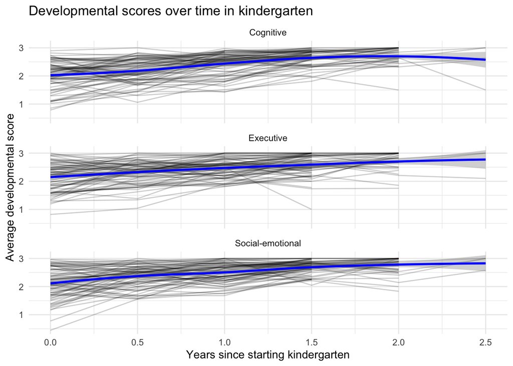

We calculate the mean, standard deviation and the number of pupils contributing to each time period for each function, to see whether scores improve overtime.

```
# A tibble: 18 × 6
   time_period development_function mean_score sd_score n_pupils     se
         <dbl> <chr>                     <dbl>    <dbl>    <int>  <dbl>
 1         0   Cognitive                  2.03    0.503       78 0.0570
 2         0   Executive                  2.15    0.496       78 0.0562
 3         0   Social-emotional           2.11    0.546       78 0.0618
 4         0.5 Cognitive                  2.18    0.419       78 0.0474
 5         0.5 Executive                  2.32    0.390       78 0.0441
 6         0.5 Social-emotional           2.37    0.379       78 0.0429
 7         1   Cognitive                  2.44    0.383       79 0.0430
 8         1   Executive                  2.47    0.333       79 0.0375
 9         1   Social-emotional           2.50    0.346       79 0.0389
10         1.5 Cognitive                  2.64    0.273       75 0.0315
11         1.5 Executive                  2.59    0.373       76 0.0428
12         1.5 Social-emotional           2.69    0.238       75 0.0275
13         2   Cognitive                  2.71    0.295       42 0.0455
14         2   Executive                  2.73    0.323       36 0.0539
15         2   Social-emotional           2.75    0.294       42 0.0454
16         2.5 Cognitive                  2.54    0.616        5 0.275
17         2.5 Executive                  2.7     0.520        3 0.3
18         2.5 Social-emotional           2.89    0.211        4 0.105
```

Next, we visualize how average developmental function scores change over time in kindergarten. Larger points indicate that more pupil observations contributed data.

[figure not shown]

Finally, we fitted separate mixed-effect models for each function, and adjusted the p-values to account for testing multiple functions.

As shown below, the results suggest that all three functions have a statistically significant positive relationship with kindergarten duration (p values where p<0.05). Cognition has the largest estimated increase (0.195 per 6 months), followed by social-emotional (0.171) and executive development (0.150).

```
# A tibble: 3 × 4
  development_function estimate  p_value p_adjusted
  <chr>                   <dbl>    <dbl>      <dbl>
1 Cognitive               0.391 5.89e-40   1.77e-39
2 Executive               0.300 3.40e-28   3.40e-28
3 Social-emotional        0.342 2.89e-36   4.34e-36
```

#### Conclusion - Kindergarten duration and developmental functioning

The above analysis suggests that the three development functions (cognitive, social-emotional and executive development), as measured by pupil’s scores in their observations, tend to increase the longer the pupils stay in kindergarten. For every additional 6 months, cognitive function increased by almost 0.2 points, while social-emotional by 0.17 and executive development by 0.15.

The model results showed statistical significance between kindergarten duration and each developmental function, meaning that these relationships are unlikely to be due to random variation alone.

Overall, the findings show that pupils tend to attain higher developmental scores as their time spent in kindergarten increases. It is not proven that this is a causal relationship.

## Time spent in kindergarten and functioning in Years 3 & 4

To address the second part of the RQ1, which questions how the duration of kindergarten affects functioning in Years 3 & 4, we first look at the cito test scores from these pupils.

Created by Cito (Central Institute for Test Development), these tests measure primary school pupils’ academic progress throughout the years and help guide their secondary school placement. Here, we will use these test results to reflect their levels of academic achievement in grades 3 and 4.

We must check if the data have any missing values, and especially if any pupils from the kindergarten duration data are not included in the cito data.

```
 [1] "Adam Willems"         "Elif Van Doorn"       "Elin Arslan"
 [4] "Emma Van der Meer"    "Evi Kok"              "Evi Van Wijk"
 [7] "Finn Koster"          "Fleur Hendriks"       "Gijs Karaca"
[10] "Jens Dijkstra"        "Jesse Vermeulen"      "Maud Van der Linden"
[13] "Max Smits"            "Mees Yilmaz"          "Milan Hassan"
[16] "Noud Kok"             "Olivier Van der Meer" "Rayan Bos"
[19] "Rayan Groen"          "Sam Van Vliet"        "Sophie Peters"
[22] "Tess Bouazizi"        "Tess Karaca"          "Timo Ozturk"
[25] "Yara El Idrissi"
```

```
[1] 25
```

```
[1] 33
```

25 students will be excluded from the analysis linking kindergarten to Cito performance because their Cito scores are unavailable. This reduces the sample size of pupils to 54.

Below we find that 17 cito scores and 16 performance band values are missing. We inspect in which rows these are, and find that all missing performance band values coincide with missing test scores, while one additional test score is missing despite having a performance band value. We therefore remove the rows with missing data and check whether this results in any additional pupils being excluded. We find that this is not the case, the number of excluded pupils remains 25.

```
            Grade Assessment period              Test             Score
                0                 0                 0                17
 Performance band              Name
               16                 0
```

```
 [1] 145 213 233 339 501 563 566 568 569 571 572 579 580 582 583 584 586
```

```
 [1] 213 233 339 501 563 566 568 569 571 572 579 580 582 583 584 586
```

```
            Grade Assessment period              Test             Score
                0                 0                 0                 0
 Performance band              Name
                0                 0
```

```
 [1] "Adam Willems"         "Elif Van Doorn"       "Elin Arslan"
 [4] "Emma Van der Meer"    "Evi Kok"              "Evi Van Wijk"
 [7] "Finn Koster"          "Fleur Hendriks"       "Gijs Karaca"
[10] "Jens Dijkstra"        "Jesse Vermeulen"      "Maud Van der Linden"
[13] "Max Smits"            "Mees Yilmaz"          "Milan Hassan"
[16] "Noud Kok"             "Olivier Van der Meer" "Rayan Bos"
[19] "Rayan Groen"          "Sam Van Vliet"        "Sophie Peters"
[22] "Tess Bouazizi"        "Tess Karaca"          "Timo Ozturk"
[25] "Yara El Idrissi"
```

```
[1] 25
```

We join the Cito data with the kindergarten duration data, matching by pupil’s names.

```
[1] 0
```

Dividing kindergarten duration into six-month intervals here results in groups with too few pupils to reliably compare them. Since the average (mean) time in kindergarten is approximately two years, we divide the pupils into two groups: those who spent two years or less in kindergarten, and those who spent more. The groups now allow for a more practical comparison of their cito scores.

```
[1] 2.002912
```

```
# A tibble: 2 × 2
  duration_group        n
  <chr>             <int>
1 2 years or less      22
2 more than 2 years    32
```

Below we calculate the number and percentage of pupils in each performance band to compare the distribution of the bands between the two duration groups.

```
# A tibble: 40 × 5
   Test        duration_group    `Performance band`     n percentage
   <chr>       <chr>             <chr>              <int>      <dbl>
 1 Mathematics 2 years or less   I                      6       8.82
 2 Mathematics 2 years or less   II                     5       7.35
 3 Mathematics 2 years or less   III                   11      16.2
 4 Mathematics 2 years or less   IV                    14      20.6
 5 Mathematics 2 years or less   V                     32      47.1
 6 Mathematics more than 2 years I                     11      11.5
 7 Mathematics more than 2 years II                    12      12.5
 8 Mathematics more than 2 years III                   16      16.7
 9 Mathematics more than 2 years IV                    19      19.8
10 Mathematics more than 2 years V                     38      39.6
# ℹ 30 more rows
```

The plot below compares the distribution of the performance bands per test between pupils who spent two years or less in kindergarten, and those who spent more. The results combine all cohorts and assessment periods together.

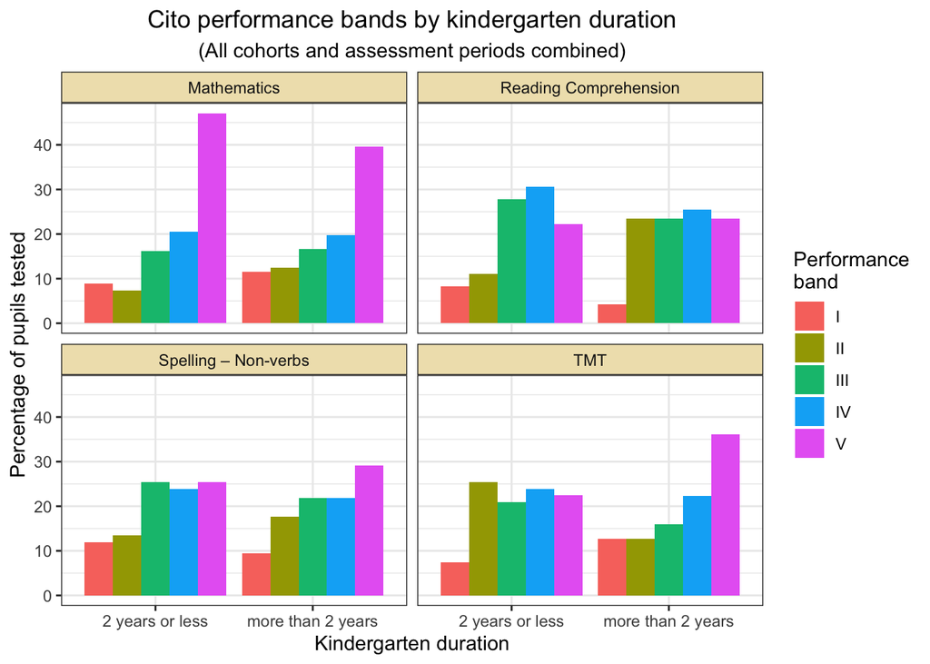

According to the above visualization, spending longer (more than two years) in kindergarten does not have a consistent advantage in functioning in Years 3 & 4 in terms of Cito test scores. Pupils with longer kindergarten periods show higher performance in TMT, and, to a lesser extent, spelling (non-verbs). However, there is no clear advantage in reading comprehension, while mathematics shows a lowered number of pupils in the top-performing band for longer kindergarten periods. These patterns suggest that any associations between kindergarten duration and Cito test performance are likely subject-specific rather than general.

# RQ2: Teaching focus on Year 3 objectives

*What effects does a teaching focus on learning objectives aligned with Years 3 and 4 have on pupils’ academic achievement and subsequent educational pathways?*

## Approach in short

The school has selected 15 learning goals that pupils should reach **before** they start group 3 (file `Selected learning goals.xlsx`, sheet 2). For RQ2 we ask: do pupils who mastered more of these goals by the end of kindergarten do better in Year 3 and 4?

| Role | Variable | Source file |
| --- | --- | --- |
| Predictor | % of the 15 Year 3 goals mastered at the end of kindergarten | `Observaties_groep_1_2.xlsx` |
| Outcome: achievement | Cito scores in Year 3 (mid and end) and Year 4 (end) for Mathematics, TMT (reading speed) and Spelling | `Cito_UvA_EN.xlsx` |
| Outcome: falling behind | Cito performance band IV or V (bottom 40% nationally) | `Cito_UvA_EN.xlsx` |
| Outcome: keeping up with lessons | % of test goals passed in the school’s own maths tests, Year 3 and 4 | `UvA_testresults_math.xlsx` |
| Outcome: pathway | Academic support needed (started or waiting list) and received in Year 3 | `Support interventions_care team.xlsx` |
| Controls | Age at the start of Year 3, cohort (current group) | `Pupils.xlsx` |

The steps below are: (1) select pupils, (2) identify the Year 3 goals, (3) clean the observation scores, (4) compute mastery per pupil, (5) build the Cito and support outcomes, (6) combine everything into one dataset, and (7) analyse it.

## 1. Pupils

We start from the same pupils as RQ1 (`pupil_selection`, groups 3-7). Unlike RQ1, pupils who failed the kindergarten checks are **kept**, because repeating a year is itself a possible RQ2 outcome.

The files do not share an ID: the pupil file uses `Pupil 002`, the support file `Leerling 018` and the maths file just `7`. Pupil **names** are unique in the pupil file and appear in every file, so names are used to link the files. `str_squish()` removes accidental double or trailing spaces so that names match exactly.

## 2. The Year 3 goals

Sheet 2 of `Selected learning goals.xlsx` (“Goals before grade one”) lists the 15 goals the school listed as important for a successful start in Year 3. Each goal has a code (e.g. `TG11.2_E2`) in the same format as the column `Leerpadcode` in the observations, which is how goals and observations are linked. The sheet has three title rows above the header, hence `skip = 3`.

Two other options were checked and rejected:

- `Vaktype` has a category “check”, but it only covers world orientation, crafts and performing arts, not the Year 3 goals.
- `Leercode` is a legacy column: it is filled for almost all rows until 2021/22 and empty from 2024/25 onwards (the school changed its recording system). It is therefore not used, and it is skipped when importing.

```
[1] 15
```

```
[1] 1
```

All 15 goal codes appear in the observations (share = 1).

## 3. Cleaning the observation scores

Teachers score each goal on a scale of 0-4, which in practice is 0-3. The score distribution showed:

- mostly 0, 1, 2 and 3;
- a few half scores (1.5, 2.5, 3.5), which are kept;
- 406 scores of 4, which are recoded to 3 (the highest level used in practice);
- three impossible scores (5 and 22), which are set to missing (`NA`).

## 4. Mastery per pupil (the predictor)

A goal is usually observed several times during kindergarten. We want to know where a pupil **ended up** before Year 3, so for each pupil and goal only the **most recent** score is kept (`arrange(desc(Datum))` puts the latest date first, `slice(1)` keeps that row).

A goal counts as **mastered** when that last score is 3 (the highest level). Then, per pupil:

- `n_goals_observed`: how many of the 15 goals were observed at all;
- `pct_mastered`: mastered goals as a % of all 15 goals (main measure; a goal that was never observed counts as not mastered);
- `pct_mastered_2`: the same, but with score 2 or higher counting as mastered (robustness check);
- `pct_of_observed`: mastered goals as a % of the goals that were observed (robustness check for pupils with incomplete records).

### Table 2 requested by the school

I believe this is what the school asked for: how many goals were designated as important for Year 3, what % of these pupils have mastered on average when starting Year 3, and the lowest and highest values across pupils.

```
# A tibble: 1 × 6
  n_goals n_pupils mean_pct min_pct max_pct mean_pct_ge2
    <int>    <int>    <dbl>   <dbl>   <dbl>        <dbl>
1      15      101     67.9    13.3     100         82.9
```

**Interpretation.** On average pupils mastered about two thirds (68%) of the 15 goals by the start of Year 3, with large differences between pupils (from 13% to 100%). With the looser definition (score 2 or higher), the average is 83%.

### How complete are the records per group?

If a pupil’s record is incomplete, the main measure underestimates their mastery. This table compares the groups.

```
# A tibble: 5 × 5
  curr_year_group     n mean_goals_observed mean_pct mean_pct_observed
            <dbl> <int>               <dbl>    <dbl>             <dbl>
1               3    26                13.5     66.4              73.2
2               4    29                14.7     74.9              76.5
3               5    15                14.2     66.2              69.8
4               6    14                14.7     84.8              86.4
5               7    17                10.1     45.9              68.3
```

**Interpretation.** Groups 3-6 have nearly complete records (13.5-14.7 of the 15 goals observed). Group 7 has on average only about 10 goals observed, and their mastery drops from 68% (of observed goals) to 46% (of all goals): the gap comes from missing observations, not lower mastery. This matches the RQ1 finding that their kindergarten records stop in December. **Group 7 is therefore excluded from the outcome analysis.**

## 5a. Outcomes: Cito results

The Cito workbook has one sheet per cohort (`CLASS_2028` to `CLASS_2031`). They are read in and stacked into one table. Some cleaning is needed:

- **Column names** are made lower case with underscores (`Assessment period` -> `assessment_period`).
- **`assessment_period`** holds two things, e.g. `"end 2022-2023"`. It is split into `period` (mid/end) and `school_year`.
- **Which score?** The Cito file has four related columns:

| Column | What it is | Comparable between… | Used? |
| --- | --- | --- | --- |
| `score` | Cito’s ability scale (*vaardigheidsscore*): correct answers converted to one long scale that runs through primary school, like a height chart. For TMT it is the number of words read correctly in three… | **Moments** within the same test (it rises with age), so progress can be computed. **Not** between tests: maths and spelling have their own scales. | **Yes**: main outcome, always per test. |
| `ability_score` | A relative score (0-5): the pupil’s position compared with pupils nationally. Its mean is about 2.2 in every grade, and it rises from band V (mean 1.1) to band I (mean 4.2). | Between tests and grades. | **No**: missing for 82% of the Grade 3 results. |
| `performance_band` | National norm group, I-V, each 20% of pupils: I = top 20%, V = bottom 20%. Based on the score, using the cut-offs in the “Score ranges” sheet. “I+” is treated as I. | Between tests and moments. | **Yes**: band IV or V counts as *behind*. |
| `performance_band_value` | Meant as the band as a number, but inconsistent (band I has values 2.0-5.0). | Not reliable. | **No**. |

Band V is by far the most common band at this school, so being “behind” nationally is common here; this is important context for the results.

- **Falling behind.** `performance_band` (I-V) compares a pupil with national norms: I is the top 20%, V the bottom 20%. “I+” is treated as I. Band IV or V counts as *behind*. The column `performance_band_value` is inconsistent and is not used.
- **Tests.** Only Mathematics, TMT (reading speed) and Spelling (non-verbs) are used, because these were tested in Grade 3 in every school year. Reading Comprehension is missing in Grade 3 for two of the four years.

```
# A tibble: 21 × 4
   test                 grade   missing_score     n
   <chr>                <chr>   <lgl>         <int>
 1 Mathematics          Grade 3 FALSE           175
 2 Mathematics          Grade 3 TRUE              2
 3 Mathematics          Grade 4 FALSE           108
 4 Mathematics          Grade 4 TRUE              1
 5 Mathematics          Grade 5 FALSE            65
 6 Mathematics          Grade 5 TRUE              4
 7 Mathematics          Grade 6 FALSE            36
 8 Spelling – Non-verbs Grade 3 FALSE           175
 9 Spelling – Non-verbs Grade 3 TRUE              2
10 Spelling – Non-verbs Grade 4 FALSE           108
# ℹ 11 more rows
```

### Repeaters

A pupil with results for the **same grade in two different school years** has repeated that year. This is checked here because repeating is a possible pathway outcome.

```
# A tibble: 2 × 2
  repeated_year     n
  <lgl>         <int>
1 FALSE            88
2 TRUE              1
```

Only one pupil repeated a year. That is too few to analyse, so repeating is reported descriptively but not used as an outcome.

### One row per pupil

The Cito data has one row per pupil per test per moment. For the analysis we need one row per pupil, with a column for each test and moment (e.g. `score_math_g3_mid` = maths score in the middle of Year 3). `pivot_wider()` does this. For the repeater, only the **first attempt** is used (`arrange(school_year)` then `slice(1)`), because that reflects the level they started Year 3 with.

`math_progress` is the gain in maths from the middle of Year 3 to the end of Year 4.

## 5b. Outcomes: support in Year 3

The support file records each referral with the school year (e.g. `2324` = 2023/24), but not the pupil’s group at that time. The group is worked out from the current group:

> group at that time = current group - (2026 - start year of that school year)

For example, a pupil now in group 5 was in group 3 in 2024/25.

Choices made:

- Only support that actually **started** is counted (`Started? = Yes`); referrals on the waiting list are not.
- **Academic support** means remedial teaching, a language group or 1:1 speech therapy. Motor therapy and behaviour support are less related to being ready in Year 3.
- The file covers 2023/24 to 2025/26, so Year 3 support is only known for pupils now in groups 4-6. For them, a pupil **without a record** is assumed to have received **no support**.

## 6. Analysis dataset

Everything is joined into one table with **one row per pupil** in groups 4-6:

- group 3 is left out because they have no Year 3 Cito results yet;
- group 7 is left out because their kindergarten records are incomplete.

Two control variables are added:

- **age at the start of Year 3** (Year 3 starts on 1 September of 2026 - (current group - 3));
- **winter birthday** (born October-December), a group the school specifically asked about.

```
# A tibble: 3 × 2
  curr_year_group     n
            <dbl> <int>
1               4    30
2               5    16
3               6    14
```

```
# A tibble: 7 × 2
  variable                n_non_missing
  <chr>                           <int>
1 pct_mastered                       58
2 score_math_g3_mid                  59
3 score_tmt_g3_mid                   59
4 score_spelling_g3_mid              58
5 math_progress                      30
6 any_academic_support_y3            60
7 age_year3                          60
```

**Interpretation.** The analysis sample has 60 pupils (30 in group 4, 16 in group 5, 14 in group 6). Mastery and the Year 3 mid scores are available for 58-59 of them. `math_progress` is only available for 30 pupils, because current group 4 has not taken the end-of-Year-4 test yet.

## 7. Analysis

### 7a. Lower vs higher mastery

As a first, simple comparison, pupils are split at the median of `pct_mastered` into a “lower” and a “higher” mastery group.

```
# A tibble: 2 × 10
  mastery_group     n mean_mastery math_g3_mid tmt_g3_mid spelling_g3_mid
  <chr>         <int>        <dbl>       <dbl>      <dbl>           <dbl>
1 higher           30         88.4        113.      16.6             141.
2 lower            28         60.7         88        9.33            109.
# ℹ 4 more variables: pct_behind_math <dbl>, pct_behind_tmt <dbl>,
#   pct_acad_support <dbl>, math_progress <dbl>
```

**Interpretation.** Pupils with higher mastery score higher on all three tests in the middle of Year 3. They are also much less often behind: in maths, roughly 4 in 10 pupils with higher mastery are in band IV/V, compared with roughly 8 in 10 pupils with lower mastery.

### 7b. Mastery and Year 3 scores

Each dot is a pupil; the black line is a linear fit with its 95% confidence band.

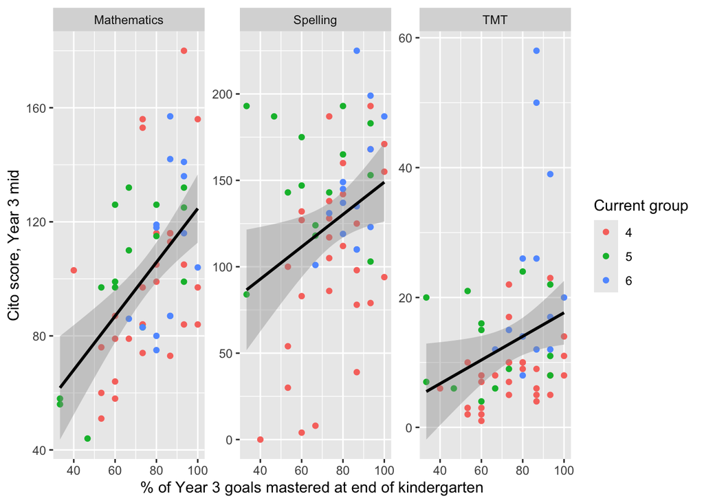

### 7c. Regression

A linear regression estimates how much the Year 3 score changes per percentage point of mastery, while holding age at the start of Year 3 and cohort constant. Cohort (`factor(curr_year_group)`) is included because each group took the Year 3 test in a different school year. Pupils with a missing value on any variable in a model are left out of that model.

```
Call:
lm(formula = score_math_g3_mid ~ pct_mastered + age_year3 + factor(curr_year_group),
    data = rq2_data)

Residuals:
    Min      1Q  Median      3Q     Max
-33.430 -19.541  -4.479   8.791  65.803

Coefficients:
                         Estimate Std. Error t value Pr(>|t|)
(Intercept)              114.0811    64.1174   1.779    0.081 .
pct_mastered               1.0654     0.2173   4.903 9.67e-06 ***
age_year3                -15.3547    10.1824  -1.508    0.138
factor(curr_year_group)5   9.8554     8.3390   1.182    0.243
factor(curr_year_group)6   0.7922     8.4894   0.093    0.926
---
Signif. codes:  0 '***' 0.001 '**' 0.01 '*' 0.05 '.' 0.1 ' ' 1

Residual standard error: 25.14 on 52 degrees of freedom
  (3 observations deleted due to missingness)
Multiple R-squared:  0.3399,    Adjusted R-squared:  0.2891
F-statistic: 6.693 on 4 and 52 DF,  p-value: 0.0002011
```

```
Call:
lm(formula = score_tmt_g3_mid ~ pct_mastered + age_year3 + factor(curr_year_group),
    data = rq2_data)

Residuals:
    Min      1Q  Median      3Q     Max
-15.167  -5.173  -1.555   2.230  34.845

Coefficients:
                         Estimate Std. Error t value Pr(>|t|)
(Intercept)              17.01830   22.33104   0.762   0.4494
pct_mastered              0.11962    0.07697   1.554   0.1262
age_year3                -2.79485    3.48997  -0.801   0.4269
factor(curr_year_group)5  5.37181    3.03827   1.768   0.0829 .
factor(curr_year_group)6 13.35496    3.04213   4.390 5.58e-05 ***
---
Signif. codes:  0 '***' 0.001 '**' 0.01 '*' 0.05 '.' 0.1 ' ' 1

Residual standard error: 9.02 on 52 degrees of freedom
  (3 observations deleted due to missingness)
Multiple R-squared:  0.3494,    Adjusted R-squared:  0.2993
F-statistic: 6.981 on 4 and 52 DF,  p-value: 0.0001413
```

```
Call:
lm(formula = score_spelling_g3_mid ~ pct_mastered + age_year3 +
    factor(curr_year_group), data = rq2_data)

Residuals:
    Min      1Q  Median      3Q     Max
-87.662 -27.732  -3.093  22.260  96.750

Coefficients:
                         Estimate Std. Error t value Pr(>|t|)
(Intercept)              202.0145   106.5618   1.896 0.063666 .
pct_mastered               1.2089     0.3611   3.348 0.001536 **
age_year3                -30.1657    16.9129  -1.784 0.080440 .
factor(curr_year_group)5  54.1911    14.0890   3.846 0.000335 ***
factor(curr_year_group)6  29.4128    14.0897   2.088 0.041854 *
---
Signif. codes:  0 '***' 0.001 '**' 0.01 '*' 0.05 '.' 0.1 ' ' 1

Residual standard error: 41.73 on 51 degrees of freedom
  (4 observations deleted due to missingness)
Multiple R-squared:  0.3619,    Adjusted R-squared:  0.3119
F-statistic: 7.233 on 4 and 51 DF,  p-value: 0.0001081
```

**Interpretation.**

- **Mathematics:** each extra 10 percentage points of mastery goes with about 11 points higher on the Year 3 mid Cito maths score (b = 1.07 per point, p < .001, n = 57).
- **Spelling:** about 12 points higher per 10 percentage points (b = 1.21, p = .002, n = 56).
- **TMT (reading speed):** a positive but not significant relation (b = 0.12, p = .13). TMT differs mainly between cohorts, and a few very high scores influence the line.
- The models explain about a third of the differences between pupils (R² ≈ .34-.36). Age at the start of Year 3 is negatively related to scores, but not significantly.

### 7d. Robustness checks

Do the maths results depend on the choices made above? Three checks:

1. a looser definition of mastery (score 2 or higher);
2. mastery as a % of the goals that were actually observed;
3. leaving out pupils who are far from the regression line (standardised residual larger than 2.5).

For check 3 the model is first refitted on the pupils without missing values, so that the residuals line up with the right pupils.

```
Call:
lm(formula = score_math_g3_mid ~ pct_mastered_2 + age_year3 +
    factor(curr_year_group), data = rq2_data)

Residuals:
    Min      1Q  Median      3Q     Max
-38.211 -22.712  -2.278  13.224  70.619

Coefficients:
                         Estimate Std. Error t value Pr(>|t|)
(Intercept)               50.7041    80.4866   0.630  0.53147
pct_mastered_2             1.3959     0.4915   2.840  0.00642 **
age_year3                -12.9897    11.4476  -1.135  0.26170
factor(curr_year_group)5  15.0680    10.4497   1.442  0.15531
factor(curr_year_group)6   6.1083     9.4180   0.649  0.51947
---
Signif. codes:  0 '***' 0.001 '**' 0.01 '*' 0.05 '.' 0.1 ' ' 1

Residual standard error: 28.29 on 52 degrees of freedom
  (3 observations deleted due to missingness)
Multiple R-squared:  0.1643,    Adjusted R-squared:  0.1001
F-statistic: 2.556 on 4 and 52 DF,  p-value: 0.04953
```

```
Call:
lm(formula = score_math_g3_mid ~ pct_of_observed + age_year3 +
    factor(curr_year_group), data = rq2_data)

Residuals:
    Min      1Q  Median      3Q     Max
-33.430 -17.542  -1.543   8.815  60.911

Coefficients:
                         Estimate Std. Error t value Pr(>|t|)
(Intercept)               95.8610    64.3925   1.489    0.143
pct_of_observed            1.0891     0.2189   4.974 7.53e-06 ***
age_year3                -12.9963    10.0866  -1.288    0.203
factor(curr_year_group)5   8.0883     8.2250   0.983    0.330
factor(curr_year_group)6   0.5068     8.4594   0.060    0.952
---
Signif. codes:  0 '***' 0.001 '**' 0.01 '*' 0.05 '.' 0.1 ' ' 1

Residual standard error: 25.03 on 52 degrees of freedom
  (3 observations deleted due to missingness)
Multiple R-squared:  0.3459,    Adjusted R-squared:  0.2956
F-statistic: 6.876 on 4 and 52 DF,  p-value: 0.0001606
```

```
Call:
lm(formula = score_math_g3_mid ~ pct_mastered + age_year3 + factor(curr_year_group),
    data = rq2_trim)

Residuals:
    Min      1Q  Median      3Q     Max
-33.857 -18.381  -3.082   8.435  58.934

Coefficients:
                         Estimate Std. Error t value Pr(>|t|)
(Intercept)              137.0061    60.5634   2.262   0.0280 *
pct_mastered               1.0879     0.2036   5.342 2.15e-06 ***
age_year3                -19.6782     9.6520  -2.039   0.0467 *
factor(curr_year_group)5  12.0666     7.8462   1.538   0.1303
factor(curr_year_group)6   2.9430     7.9844   0.369   0.7140
---
Signif. codes:  0 '***' 0.001 '**' 0.01 '*' 0.05 '.' 0.1 ' ' 1

Residual standard error: 23.54 on 51 degrees of freedom
Multiple R-squared:  0.3954,    Adjusted R-squared:  0.348
F-statistic:  8.34 on 4 and 51 DF,  p-value: 2.96e-05
```

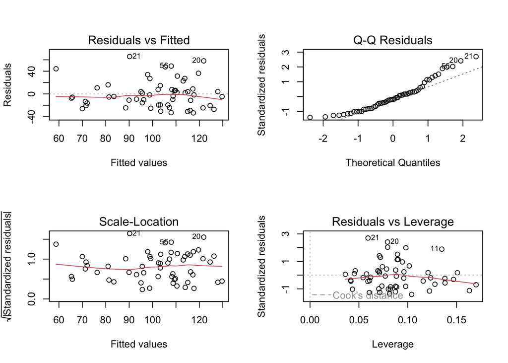

**Interpretation.** The maths result holds in all three checks: with a looser definition of mastery the relation is weaker but still significant (b = 1.40, p = .006); as a % of observed goals it is almost identical (b = 1.09, p < .001); and without extreme pupils it is the same (b = 1.09, p < .001). The diagnostic plots show some right skew in the residuals (a few pupils score much higher than predicted), but no influential outliers and roughly constant variance.

### 7e. Later moments: end of Year 3, end of Year 4 and progress

The analysis above used the middle of Year 3. Here the same model is applied to later moments, to see whether the relation with mastery lasts. One row per outcome: `b` is the change in score per percentage point of mastery (controlling for age at the start of Year 3 and cohort).

- End of Year 4 scores and maths progress (mid Year 3 to end Year 4) are only available for current groups 5 and 6 (about 30 pupils).

```
# A tibble: 10 × 6
   outcome                   b    se         p     n    r2
   <chr>                 <dbl> <dbl>     <dbl> <int> <dbl>
 1 score_math_g3_mid      1.07  0.22 0.0000097    57  0.34
 2 score_math_g3_end      0.86  0.21 0.00019      58  0.31
 3 score_math_g4_end      1.4   0.32 0.0002       29  0.5
 4 score_spelling_g3_mid  1.21  0.36 0.0015       56  0.36
 5 score_spelling_g3_end  0.78  0.27 0.0062       58  0.24
 6 score_spelling_g4_end  0.8   0.5  0.12         29  0.26
 7 score_tmt_g3_mid       0.12  0.08 0.13         57  0.35
 8 score_tmt_g3_end       0.07  0.1  0.48         57  0.26
 9 score_tmt_g4_end       0.12  0.2  0.54         28  0.11
10 math_progress          0.24  0.23 0.3          29  0.19
```

**Interpretation.** The relation between mastery and maths lasts: it is significant in the middle of Year 3 (b = 1.07), at the end of Year 3 (b = 0.86) and at the end of Year 4 (b = 1.40, n = 29). For spelling it lasts through Year 3 (b = 0.78 at the end of Year 3); at the end of Year 4 it is still positive but not significant, which may be due to the small sample (n = 29). For reading speed (TMT) there is no relation at any moment. Pupils with higher mastery do **not** make faster progress in maths from mid Year 3 to end Year 4 (b = 0.24, p = .30): they start Year 3 at a higher level and keep that lead, but the gap does not grow.

### 7f. Falling behind over time

Share of pupils in band IV or V, per test and moment, for pupils with lower and higher mastery.

```
# A tibble: 9 × 6
  test     moment n_higher n_lower pct_behind_higher pct_behind_lower
  <chr>    <chr>     <int>   <int>             <dbl>            <dbl>
1 math     g3_end       30      28                60               79
2 math     g3_mid       30      27                43               81
3 math     g4_end       17      12                35               83
4 spelling g3_end       30      28                30               71
5 spelling g3_mid       30      26                47               73
6 spelling g4_end       17      12                29               67
7 tmt      g3_end       29      28                45               64
8 tmt      g3_mid       30      27                47               70
9 tmt      g4_end       17      12                24               67
```

**Interpretation.** At every moment, pupils with lower mastery are more often behind (band IV/V) than pupils with higher mastery: 64-83% versus 24-60%. The difference does not disappear over time; at the end of Year 4, 83% of the lower group is behind in maths, compared with 35% of the higher group. Note that the end-of-Year-4 figures are based on only 29 pupils.

### 7g. The school’s own maths tests

These are the tests that come with the maths method: after each block of lessons, pupils take a test on what was just taught. They show whether pupils keep up with the lessons, while Cito compares pupils nationally.

```
 [1] "leerling"       "Leerlingnummer" "blok"           "toetsdoel"
 [5] "Vragen goed"    "Aantal vragen"  "score"          "behaald"
 [9] "datum"          "Cohort"
```

```
# A tibble: 4 × 2
  Cohort     n
   <dbl> <int>
1   2028  3239
2   2029  1631
3   2030  1199
4   2031  1121
```

```
# A tibble: 31 × 2
   blok      n
   <chr> <int>
 1 3.2     455
 2 3.3     445
 3 3.4     330
 4 3.5     425
 5 3.6     517
 6 3.7     515
 7 3.8     255
 8 4.1     330
 9 4.2     330
10 4.3     330
# ℹ 21 more rows
```

```
# A tibble: 2 × 2
  behaald     n
    <dbl> <int>
1       0  2213
2       1  4977
```

```
# A tibble: 20 × 2
   toetsdoel     n
   <chr>     <int>
 1 3.2.1        91
 2 3.2.2        91
 3 3.2.3        91
 4 3.2.4        91
 5 3.2.5        91
 6 3.3.1        89
 7 3.3.2        89
 8 3.3.3        89
 9 3.3.4        89
10 3.3.5        89
11 3.4.1        66
12 3.4.2        66
13 3.4.3        66
14 3.4.4        66
15 3.4.5        66
16 3.5.1        85
17 3.5.2        85
18 3.5.3        85
19 3.5.4        85
20 3.5.5        85
```

```
[1] "2022-10-01 UTC" "2026-07-10 UTC"
```

For each pupil we compute the share of test goals passed in Year 3 (blocks 3.x) and Year 4 (blocks 4.x). If the kindergarten goals prepare pupils for Year 3, pupils with higher mastery should pass more Year 3 test goals.

```
# A tibble: 4 × 2
  year_group     n
  <chr>      <int>
1 3           2942
2 4           2087
3 5           1315
4 6            846
```

```
# A tibble: 3 × 4
  curr_year_group n_with_y3 mean_tests_y3 n_with_y4
            <dbl>     <int>         <dbl>     <int>
1               4        30          35.5         2
2               5        15          32          15
3               6        14          32          14
```

```
# A tibble: 2 × 3
  mastery_group pct_passed_y3 pct_passed_y4
  <chr>                 <dbl>         <dbl>
1 higher                 84.6          70.1
2 lower                  66.6          51.9
```

```
Call:
lm(formula = pct_passed_y3 ~ pct_mastered + age_year3 + factor(curr_year_group),
    data = rq2_data)

Residuals:
    Min      1Q  Median      3Q     Max
-27.843 -11.932   3.262   9.204  25.800

Coefficients:
                         Estimate Std. Error t value Pr(>|t|)
(Intercept)               93.4854    35.7945   2.612   0.0117 *
pct_mastered               0.6667     0.1235   5.398 1.61e-06 ***
age_year3                -11.6298     5.5933  -2.079   0.0424 *
factor(curr_year_group)5  10.8584     4.7787   2.272   0.0272 *
factor(curr_year_group)6   9.4120     4.8820   1.928   0.0592 .
---
Signif. codes:  0 '***' 0.001 '**' 0.01 '*' 0.05 '.' 0.1 ' ' 1

Residual standard error: 14.48 on 53 degrees of freedom
  (2 observations deleted due to missingness)
Multiple R-squared:  0.4559,    Adjusted R-squared:  0.4148
F-statistic:  11.1 on 4 and 53 DF,  p-value: 1.296e-06
```

```
Call:
lm(formula = pct_passed_y4 ~ pct_mastered + age_year3 + factor(curr_year_group),
    data = rq2_data)

Residuals:
    Min      1Q  Median      3Q     Max
-40.502 -10.574   0.763  14.647  30.681

Coefficients:
                         Estimate Std. Error t value Pr(>|t|)
(Intercept)               21.1803    80.0511   0.265  0.79342
pct_mastered               0.8935     0.2444   3.655  0.00114 **
age_year3                 -3.6445    11.7655  -0.310  0.75921
factor(curr_year_group)5   2.3138    17.2740   0.134  0.89448
factor(curr_year_group)6  -8.3009    18.4968  -0.449  0.65731
---
Signif. codes:  0 '***' 0.001 '**' 0.01 '*' 0.05 '.' 0.1 ' ' 1

Residual standard error: 19.1 on 26 degrees of freedom
  (29 observations deleted due to missingness)
Multiple R-squared:  0.377, Adjusted R-squared:  0.2811
F-statistic: 3.933 on 4 and 26 DF,  p-value: 0.01257
```

**Interpretation.** Pupils with higher mastery keep up better with the maths lessons. In Year 3 they pass on average 85% of the test goals, compared with 67% for pupils with lower mastery. In the regression, every 10 percentage points of mastery goes with about 7 percentage points more test goals passed (b = 0.67, p < .001, n = 58, R² = .46). The relation is still there in Year 4 (b = 0.89, p = .001, n = 31), where pupils with higher mastery pass 70% versus 52%. In Year 3, older pupils pass fewer test goals (b = -11.6 per year of age, p = .04); this may be related to RQ1, as older pupils are often those who stayed longer in kindergarten.

Two pupils in current group 4 already have Year 4 test results, although the data ends before their Year 4; possibly they skipped a group or work at a higher level in maths. Group 4 pupils also have slightly more Year 3 tests (35 vs 32), probably retakes; this does not affect the percentage passed.

### 7h. Support in Year 3

Being on the waiting list also shows that the care team saw a need for extra support. We therefore use two measures:

- **support need**: referred for academic support in Year 3 (started or on the waiting list);
- **support received**: academic support that actually started in Year 3.

A referral counts as academic if the support type is remedial teaching, a language group or speech therapy, or if the need is learning, language or speech & language.

```
# A tibble: 3 × 3
  academic_need_y3 any_academic_support_y3     n
  <lgl>            <lgl>                   <int>
1 FALSE            FALSE                      47
2 TRUE             FALSE                       1
3 TRUE             TRUE                       12
```

```
# A tibble: 2 × 4
  mastery_group     n pct_need pct_received
  <chr>         <int>    <dbl>        <dbl>
1 higher           30     3.33          0
2 lower            28    42.9          42.9
```

```
# A tibble: 2 × 3
  academic_need_y3     n mean_mastery
  <lgl>            <int>        <dbl>
1 FALSE               47         79.9
2 TRUE                13         58.5
```

```
    Welch Two Sample t-test

data:  pct_mastered by academic_need_y3
t = 4.1176, df = 16.55, p-value = 0.0007562
alternative hypothesis: true difference in means between group FALSE and group TRUE is not equal to 0
95 percent confidence interval:
 10.40728 32.37335
sample estimates:
mean in group FALSE  mean in group TRUE
           79.85185            58.46154
```

**Interpretation.** 13 of the 60 pupils (22%) needed academic support in Year 3: 12 received it and 1 was on the waiting list. Pupils who needed support had mastered on average 58% of the Year 3 goals at the end of kindergarten, compared with 80% for pupils who did not need support, a difference of 21 percentage points (95% CI 10-32, t = 4.12, p < .001). Lower mastery at the end of kindergarten thus goes with a higher need for extra support in Year 3. With 13 pupils needing support, this result rests on a small group.

### 7i. Winter birthdays

Pupils born in October-December (“winter children”) are a group the school asked about specifically. We check (1) whether they master fewer Year 3 goals, and (2) whether the relation between mastery and Year 3 maths is different for them (interaction term `pct_mastered:winter_bdayTRUE`).

```
# A tibble: 2 × 7
  winter_bday     n mean_mastery mean_age_y3 math_g3_mid pct_passed_y3 pct_need
  <lgl>       <int>        <dbl>       <dbl>       <dbl>         <dbl>    <dbl>
1 FALSE          43         77.8        6.32       109.           78.2     18.6
2 TRUE           17         67.9        6.10        83.6          70.7     29.4
```

```
Call:
lm(formula = score_math_g3_mid ~ pct_mastered * winter_bday +
    factor(curr_year_group), data = rq2_data)

Residuals:
    Min      1Q  Median      3Q     Max
-36.560 -17.413  -1.177  10.713  59.440

Coefficients:
                             Estimate Std. Error t value Pr(>|t|)
(Intercept)                  31.20782   20.44574   1.526 0.133095
pct_mastered                  0.95734    0.25707   3.724 0.000491 ***
winter_bdayTRUE              -0.02566   33.66384  -0.001 0.999395
factor(curr_year_group)5      8.29048    8.48170   0.977 0.332958
factor(curr_year_group)6      0.49190    8.51358   0.058 0.954151
pct_mastered:winter_bdayTRUE -0.22165    0.46532  -0.476 0.635861
---
Signif. codes:  0 '***' 0.001 '**' 0.01 '*' 0.05 '.' 0.1 ' ' 1

Residual standard error: 24.89 on 51 degrees of freedom
  (3 observations deleted due to missingness)
Multiple R-squared:  0.3653,    Adjusted R-squared:  0.303
F-statistic:  5.87 on 5 and 51 DF,  p-value: 0.0002339
```

**Interpretation.** 17 of the 60 pupils (28%) were born in October-December. They were on average younger at the start of Year 3 (6.1 vs 6.3 years), so most moved on to group 3 young. On average they mastered fewer Year 3 goals (68% vs 78%), scored lower on Cito maths in the middle of Year 3 (84 vs 109), passed fewer maths test goals (71% vs 78%) and more often needed support (29% vs 19%). However, once mastery is taken into account, a winter birthday is no longer related to the maths score (b = -0.03, p = 1.00), and the relation between mastery and maths is not different for winter children (interaction b = -0.22, p = .64). In other words, winter children score lower mainly because they mastered fewer goals; at the same level of mastery, they do as well as other pupils. With 17 winter children these differences are descriptive and should be interpreted with care.

### 7j. Time spent in kindergarten

Pupils who stayed longer in kindergarten may simply have had more time to master the goals. Here we check whether mastery still predicts Year 3 maths when the time spent in kindergarten (from RQ1) is held constant. Only pupils who passed the RQ1 checks have a reliable kindergarten length.

```
[1] 0.2724951
```

```
Call:
lm(formula = score_math_g3_mid ~ pct_mastered + kg_years + factor(curr_year_group),
    data = rq2_data)

Residuals:
    Min      1Q  Median      3Q     Max
-34.719 -19.685  -2.925   8.680  63.222

Coefficients:
                         Estimate Std. Error t value Pr(>|t|)
(Intercept)               49.0752    27.7636   1.768   0.0834 .
pct_mastered               1.0094     0.2372   4.256 9.37e-05 ***
kg_years                 -11.5051    11.4695  -1.003   0.3207
factor(curr_year_group)5   7.8684     8.9519   0.879   0.3837
factor(curr_year_group)6   0.4577     8.7317   0.052   0.9584
---
Signif. codes:  0 '***' 0.001 '**' 0.01 '*' 0.05 '.' 0.1 ' ' 1

Residual standard error: 25.76 on 49 degrees of freedom
  (6 observations deleted due to missingness)
Multiple R-squared:  0.2856,    Adjusted R-squared:  0.2273
F-statistic: 4.898 on 4 and 49 DF,  p-value: 0.00211
```

```
Call:
lm(formula = pct_passed_y3 ~ pct_mastered + kg_years + factor(curr_year_group),
    data = rq2_data)

Residuals:
    Min      1Q  Median      3Q     Max
-32.143  -8.365   3.041  10.006  25.921

Coefficients:
                         Estimate Std. Error t value Pr(>|t|)
(Intercept)               38.9707    15.2695   2.552   0.0139 *
pct_mastered               0.5673     0.1305   4.349 6.92e-05 ***
kg_years                  -3.9006     6.3080  -0.618   0.5392
factor(curr_year_group)5   8.0739     4.9234   1.640   0.1074
factor(curr_year_group)6   8.5023     4.8023   1.770   0.0829 .
---
Signif. codes:  0 '***' 0.001 '**' 0.01 '*' 0.05 '.' 0.1 ' ' 1

Residual standard error: 14.17 on 49 degrees of freedom
  (6 observations deleted due to missingness)
Multiple R-squared:  0.3559,    Adjusted R-squared:  0.3034
F-statistic:  6.77 on 4 and 49 DF,  p-value: 0.0002024
```

**Interpretation.** Pupils who spent longer in kindergarten mastered slightly more of the Year 3 goals (r = 0.27). However, mastery still predicts Year 3 results when the time spent in kindergarten is held constant: for Cito maths in the middle of Year 3 (b = 1.01, p < .001, n = 54) and for the share of maths test goals passed in Year 3 (b = 0.57, p < .001, n = 54), close to the estimates without this control (1.07 and 0.67). Time in kindergarten itself is not related to these outcomes once mastery is taken into account (b = -11.5, p = .32 and b = -3.9, p = .54). In other words, what pupils have mastered matters more than how long they stayed in kindergarten; a longer stay seems to help only insofar as it leads to more goals mastered. This links RQ1 and RQ2.

## Limitations

- **Association, not effect.** Pupils who master more goals may simply be stronger learners; the data cannot separate the effect of teaching from the pupil’s own ability.
- **Mastery, not teaching focus.** All pupils received the same kind of teaching; what varies is how much they mastered. Testing the teaching focus itself would require a comparison between groups that were taught differently (e.g. before and after the school introduced the focus, or between classes 1/2a and 1/2b).
- **Small sample** (about 60 pupils), from one school.
- **Linking by name.** Files are linked on pupil names; a spelling difference would cause a pupil to be missed.
- **Support records.** It is assumed that pupils without a record did not need or receive support. Only 13 pupils needed academic support, so this result rests on a small group.
- **Outcomes not available.** Repeating a year (only 1 pupil), well-being in Year 3 and the experiences of Year 3-4 teachers (no teacher questionnaire) could not be studied.

## Conclusion RQ2

**What we did.** For about 60 pupils (current groups 4-6) we measured how many of the 15 goals the school set for the start of Year 3 each pupil had mastered at the end of kindergarten, and related this to their results and support in Years 3 and 4.

**What this means for the school.** The 15 goals appear to be a meaningful signal of readiness for Year 3: pupils who reach them start Year 3 at a higher level, keep up better and need less support. Because the gap at the start of Year 3 does not close by itself, monitoring these goals in kindergarten, and giving extra attention to pupils who have not reached them, may be a useful priority.

**How certain is this?** These are associations in a small group of pupils from one school, not proven effects of the teaching focus. Pupils who master more goals may also be stronger learners in general. To test the teaching focus itself, the school could compare groups taught with and without this focus, for example before and after the focus was introduced.

# RQ2 Visuals

Figures for the report and presentation. Each is also saved as a PNG in the folder `figures/`.

## Figure 1: lower vs higher mastery on six outcomes

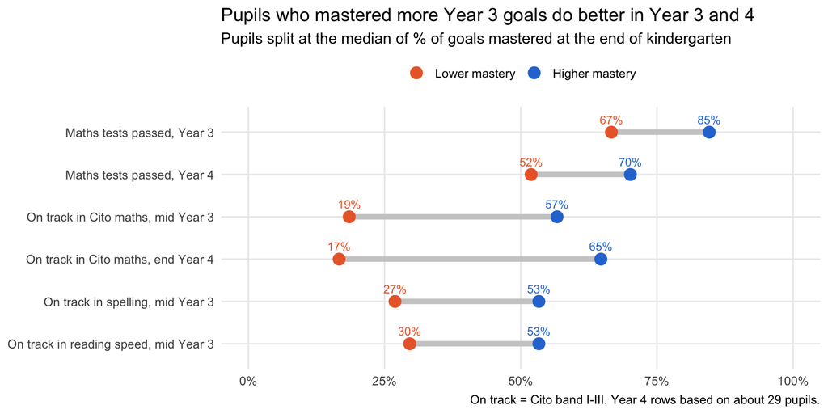

## Figure 2: mastery and Cito maths in the middle of Year 3

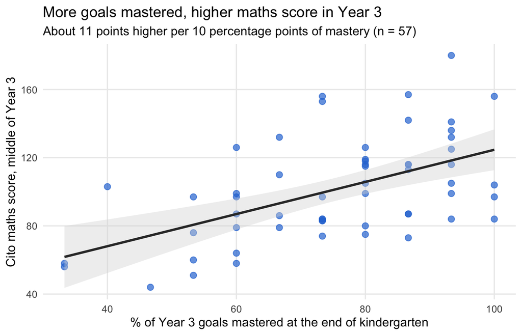

## Figure 3: mastery of pupils with and without a support need

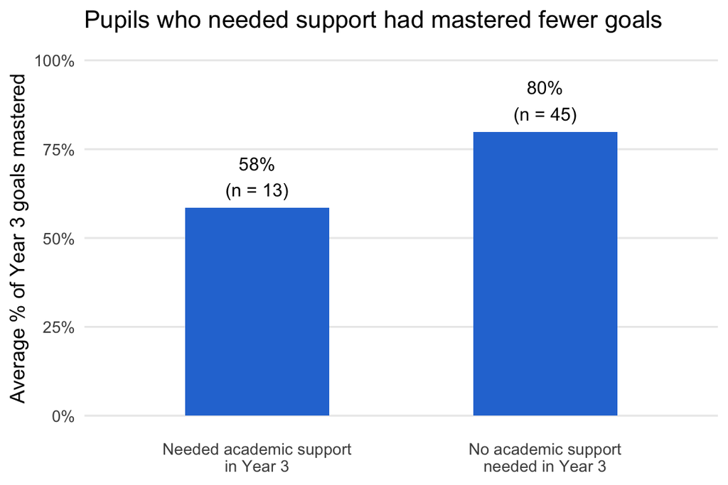